# Time Series Homework: Chapter 3 Lesson 2

I fixed some charts and code that wasn’t done very well and updated the last questions reponses.

## Data

```r
mortality <- rio::import("https://byuistats.github.io/timeseries/data/mortality_us.xlsx")
```

## Questions

### Question 1 - Context and Measurement (10 points)

The first part of any time series analysis is context. You cannot properly analyze data without knowing what the data is measuring. Without context, the most simple features of data can be obscure and inscrutable. This homework assignment will center around the series below.

Please research the time series. In the spaces below, give the data collection process, unit of analysis, and meaning of each observation for the series.

#### **US Mortality**

https://wonder.cdc.gov/wonder/help/cmf.html#

Note: The data is self-explanatory, don’t get lost in the documentation page.

**Answer**

### Question 2 - US Mortality Rate: Visualization (30 points)

##### a) Please plot the US Mortality Rate series (mortality per 100,000).

**Answer**

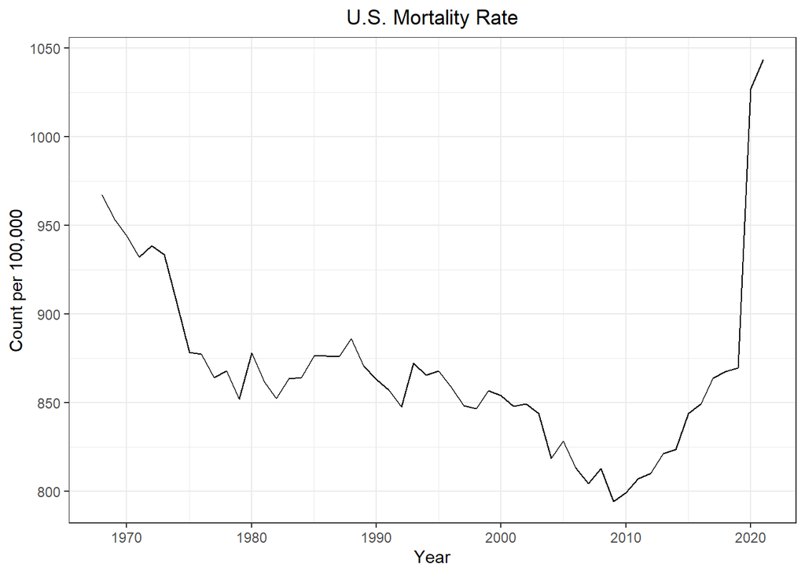

```r
ggplot(
  data = mortality,
  aes(x = year, y = `mort_rate_per_100,000`)
) +
  geom_line() +
  labs(
    title = "U.S. Mortality Rate",
    x = "Year",
    y = "Count per 100,000"
  ) +
  theme_bw() +
  theme(
    plot.title = element_text(hjust = 0.5)
  )
```

##### b) Use the exponential smoothing method to model the US Mortality Rate series. Use the smoothing parameter that R calculates by minimizing the SS1PE. Add it to the plot in 2a

**Answer**

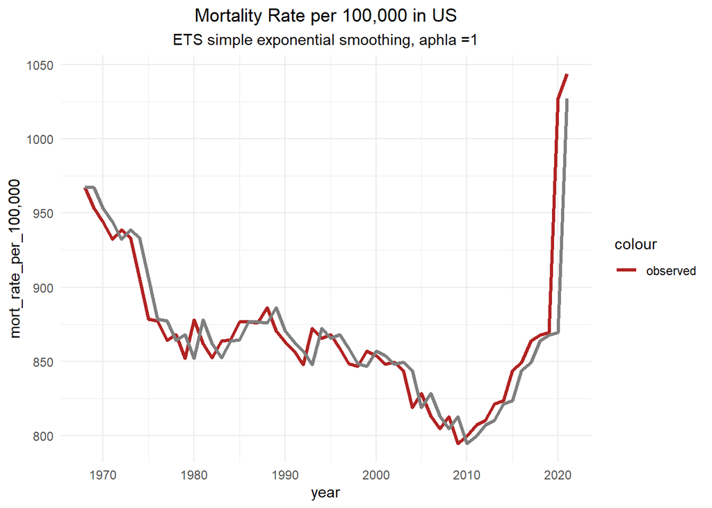

```r
library(forecast)
mortality <- mortality |> arrange(year)


y <- ts(mortality$`mort_rate_per_100,000`, start = min(mortality$year), frequency = 1)

fit_one <- ets(y, model = "ANN")
fit_two <- ets(y, model = "ANN", alpha = 0.2)
fit_three <- ets(y, model = "ANN", alpha = 1/54)

alpha <- fit_one$par["alpha"]

mortality$ETS_fit <- as.numeric(fitted(fit_one))
mortality$model_2 <- as.numeric(fitted(fit_two))
mortality$model_3 <- as.numeric(fitted(fit_three))

ggplot(mortality, aes(x = year)) +
  geom_line(aes(y = `mort_rate_per_100,000`, color = "observed"), linewidth = 1.2) +
  geom_line(aes(y = ETS_fit, color = "ETS_fit"), linewidth = 1.2) +
  scale_color_manual(values = c("observed" = "firebrick", "ETS (ANN) fit" = "steelblue")) +
  labs(
    title = 'Mortality Rate per 100,000 in US',
    subtitle = paste0("ETS simple exponential smoothing, aphla =", round(alpha, 3))
  ) +
  theme_minimal() +
  theme(
    plot.title = element_text(hjust = 0.5),
    plot.subtitle = element_text(hjust = 0.5)
  )
```

##### c) Please repeat the modeling above but instead choose a smoothing parameter value $\alpha=0.2$. Add it to the plot in 2a

**Answer**

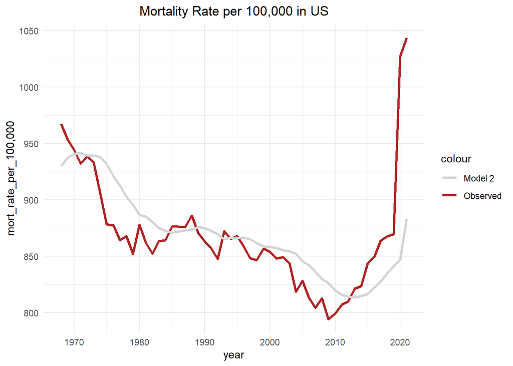

```r
ggplot(mortality, aes(x = year)) +
  geom_line(aes(y = `mort_rate_per_100,000`, color = "Observed"), linewidth = 1.2) +
  geom_line(aes(y = model_2, color = "Model 2"), linewidth = 1.2) +
  scale_color_manual(values = c("Observed" = "firebrick", "Model 1" = "steelblue", "Model 2" = "lightgray")) +
  labs(
    title = 'Mortality Rate per 100,000 in US'
  ) +
  theme_minimal() +
  theme(
    plot.title = element_text(hjust = 0.5),
    plot.subtitle = element_text(hjust = 0.5)
  )
```

##### d) Please repeat the modeling above but instead choose a smoothing parameter value $\alpha=\frac{1}{n}$.Add it to the plot in 2a

**Answer**

[figure not shown]

```r
ggplot(mortality, aes(x = year)) +
  geom_line(aes(y = `mort_rate_per_100,000`, color = "Observed"), linewidth = 1.2) +
  geom_line(aes(y = model_3, color = "Model 3"), linewidth = 1.2) +
  scale_color_manual(values = c("Observed" = "firebrick", "Model 3" = "green2")) +
  labs(
    title = 'Mortality Rate per 100,000 in US',
    subtitle = paste0("ETS simple exponential smoothing, aphla =", round(alpha, 3))
  ) +
  theme_minimal() +
  theme(
    plot.title = element_text(hjust = 0.5),
    plot.subtitle = element_text(hjust = 0.5)
  )
```

##### d) Which of the smoothing parameter values you tried before work best for the series? Justify your answer.

**Answer**

### Question 5 - US Mortality Rate: Excess Mortality (30 points)

The jump at the last two years of the US Mortality Rate series is clearly the effect that Covid-19 had on mortality across the US.

##### a) Please calculate the excess mortality rate during 2020 and 2021 using the smoothing parameter values you employed in the previous question. Your results should be displayed in a table that is professionally formatted.

**Answer**

```r
library(knitr)
mortality <- mortality |>
  mutate(
    excess = `mort_rate_per_100,000` - model_2
  )

mortality |>
  select(year, `mort_rate_per_100,000`, model_2, model_3) |>
  kable(digits = 3, caption ="ETS Model Fit Statistics Across Alpha Values") |>
  kable_styling(bootstrap_options = c("striped", "hover", "condensed"))
```

| year | mort_rate_per_100,000 | model_2 | model_3 |
| --- | --- | --- | --- |
| 1968 | 967.3 | 930.256 | 871.885 |
| 1969 | 953.5 | 937.665 | 873.652 |
| 1970 | 944.2 | 940.832 | 875.131 |
| 1971 | 932.2 | 941.506 | 876.410 |
| 1972 | 938.6 | 939.645 | 877.443 |
| 1973 | 933.5 | 939.436 | 878.576 |
| 1974 | 906.3 | 938.249 | 879.593 |
| 1975 | 878.5 | 931.859 | 880.087 |
| 1976 | 877.4 | 921.187 | 880.058 |
| 1977 | 864.2 | 912.430 | 880.009 |
| 1978 | 868.0 | 902.784 | 879.716 |
| 1979 | 852.0 | 895.827 | 879.499 |
| 1980 | 878.0 | 887.062 | 878.990 |
| 1981 | 861.9 | 885.249 | 878.971 |
| 1982 | 852.3 | 880.579 | 878.655 |
| 1983 | 863.7 | 874.924 | 878.167 |
| 1984 | 864.4 | 872.679 | 877.899 |
| 1985 | 876.6 | 871.023 | 877.649 |
| 1986 | 876.5 | 872.138 | 877.630 |
| 1987 | 876.0 | 873.011 | 877.609 |
| 1988 | 886.2 | 873.609 | 877.579 |
| 1989 | 870.6 | 876.127 | 877.739 |
| 1990 | 863.1 | 875.022 | 877.607 |
| 1991 | 857.2 | 872.637 | 877.338 |
| 1992 | 847.8 | 869.550 | 876.965 |
| 1993 | 872.4 | 865.200 | 876.425 |
| 1994 | 865.7 | 866.640 | 876.350 |
| 1995 | 868.0 | 866.452 | 876.153 |
| 1996 | 858.8 | 866.762 | 876.002 |
| 1997 | 848.4 | 865.169 | 875.684 |
| 1998 | 846.7 | 861.815 | 875.178 |
| 1999 | 857.0 | 858.792 | 874.651 |
| 2000 | 854.0 | 858.434 | 874.324 |
| 2001 | 848.0 | 857.547 | 873.948 |
| 2002 | 849.5 | 855.638 | 873.467 |
| 2003 | 843.9 | 854.410 | 873.023 |
| 2004 | 818.8 | 852.308 | 872.484 |
| 2005 | 828.4 | 845.606 | 871.490 |
| 2006 | 813.1 | 842.165 | 870.692 |
| 2007 | 804.6 | 836.352 | 869.625 |
| 2008 | 812.9 | 830.002 | 868.421 |
| 2009 | 794.5 | 826.581 | 867.393 |
| 2010 | 799.5 | 820.165 | 866.043 |
| 2011 | 807.3 | 816.032 | 864.811 |
| 2012 | 810.2 | 814.286 | 863.746 |
| 2013 | 821.5 | 813.469 | 862.754 |
| 2014 | 823.7 | 815.075 | 861.990 |
| 2015 | 844.0 | 816.800 | 861.281 |
| 2016 | 849.3 | 822.240 | 860.961 |
| 2017 | 863.8 | 827.652 | 860.745 |
| 2018 | 867.8 | 834.882 | 860.802 |
| 2019 | 869.7 | 841.465 | 860.931 |
| 2020 | 1027.0 | 847.112 | 861.094 |
| 2021 | 1043.8 | 883.090 | 864.166 |

##### b) What is the meaning of excess mortality as you calculated it? Please explain it to a general audience, as if you were being interviewed in a national news show.

**Answer**

Excess mortality measures how many more people died in a given year than we would have expected based on historical trends. In our model, we estimated what the mortality rate *should have been* if past patterns had continued smoothly over time. The ‘excess’ is simply the difference between that expected rate and the actual rate we observed.

If the number is positive, it means more people died than expected, perhaps because of a major event like a pandemic, heat wave, or natural disaster. If it’s negative, it means fewer people died than expected, which could reflect improvements in healthcare or safety

##### c) Which excess mortality rate estimate do you think is correct? Some commentators would suggest you are choosing the parameters to defend your political goals, not to conduct a scientific analysis. Please comment on the difficulty of choosing parameter values to estimate the death toll of Covid-19.

**Answer**

Using an alpha of 0.2 provides a good balance between giving weight to past data and adjusting for more recent changes. In time series analysis, choosing parameters like alpha can be difficult because it involves judgment, analysts must decide how much importance to place on historical trends versus new information. These choices can vary depending on one’s understanding of the data and the purpose of the analysis.

### Rubric

| **Criteria** | **Mastery (10)** | **Incomplete (0)** |
| --- | --- | --- |
| **Question 1: Context and Measurement** | The student thoroughly researches the data collection process, unit of analysis, and meaning of each observation for both the requested time series. Clear and comprehensive explanations are provided. | The student does not adequately research or provide information on the data collection process, unit of analysis, and meaning of each observation for the specified series. |
|  | **Mastery (5)** | **Incomplete (0)** |
| **Question 2a: Mortality Plot** | The student accurately plots the US Mortality Rate series in R, ensuring clear labeling and a descriptive title for easy interpretation. The visualization effectively presents the data with distinguis… | The student encounters challenges in plotting the US Mortality Rate series in R. The plot may lack essential labels or a descriptive title, making it difficult to interpret. Additionally, the visualiz… |
|  | **Mastery (5)** | **Incomplete (0)** |
| **Question 2b: Smoothing SS1PE** | Students use R to compute exponential smoothing for modeling the US Mortality Rate series. Their R code is well-commented, providing clear explanations for each step of the process, ensuring transpare… | Students may encounter challenges in implementing exponential smoothing in R, resulting in incomplete or ineffective computations. Their R code might lack sufficient comments, hindering clarity in und… |
|  | **Mastery (5)** | **Incomplete (0)** |
| **Question 2c: Smoothing a=0.2** | Students employ R to repeat the modeling of the US Mortality Rate series using a specified smoothing parameter value of alpha=0.2. Their R code is well-commented, providing clear explanations for each… | Students may encounter challenges in implementing exponential smoothing in R, resulting in incomplete or ineffective computations. Their R code might lack sufficient comments, hindering clarity in und… |
|  | **Mastery (5)** | **Incomplete (0)** |
| **Question 2d: Smoothing a=1/n** | Students employ R to repeat the modeling of the US Mortality Rate series using a specified smoothing parameter value of alpha=1/n. Their R code is well-commented, providing clear explanations for each… | Students may encounter challenges in implementing exponential smoothing in R, resulting in incomplete or ineffective computations. Their R code might lack sufficient comments, hindering clarity in und… |
|  | **Mastery (10)** | **Incomplete (0)** |
| **Question 2d: Evaluation of Parameter Choice** | Students justify their choice of parameter in the context of the underlying factors affecting US Mortality Rates evident in the data. The students evidence their understanding of the implications of t… | Students fail to adequately justify their choice of parameter in relation to the underlying factors affecting US Mortality Rates evident in the data. They may lack evidence of understanding the implic… |
|  | **Mastery (10)** | **Incomplete (0)** |
| **Question 3a: Excess MortalityTable** | Students accurately calculate the excess mortality rate during 2020 and 2021 using the smoothing parameter values employed in the previous question. They present their results in table, clearly displa… | Students demonstrate inaccuracies in calculating the excess mortality rate during 2020 and 2021. Their presentation of the results in a table may lack clarity and professionalism, with issues such as … |
|  | **Mastery (10)** | **Incomplete (0)** |
| **Question 3b: Excess Mortality** | Explanations effectively convey the meaning of excess mortality to a general audience, avoiding technical terms and providing a clear, accessible description. They define excess mortality as the numbe… | Responses may struggle to explain excess mortality clearly to a general audience, potentially using technical language or lacking coherence. They may fail to provide relatable examples or context, mak… |
|  | **Mastery (10)** | **Incomplete (0)** |
| **Question 3c: Evaluation of assumptions used for inference** | Responses address the challenge of selecting parameter values to make inference in time series. They provide a comprehensive analysis, considering factors like modeling assumptions, and methodological… | Below expectations, responses may lack depth or clarity in addressing the challenge of selecting parameter values for making inference in time series. They may overlook key factors influencing paramet… |
| **Total Points** | **70** |  |